# FAsimUpdate

Lan Luo

2022-05-13

## Recap

The previous simulation (simple 2 factor simulation) did not seem to follow the true DGM. Here I simulate a one factor model to double check where is going wrong.

After hand computing the covariances for observed variables and their error terms, and trying other packages to simulate multivariate normal distribution data, it appears that the simulation not following specified model structure is due to some issues with one particular function when generating the data. Below I demonstrate how that’s the case and how it can be solved - we could either switch to another random number generating function, or generate the observed data directly from the observed variables’ covariance matrix.

## One factor simulation

A very simple one factor model. The value of the error covariance matrix is determined by setting all R2 values to .8. Following the equations 1, V(X) = lambda^2 * V(Latent) + V(error), and 2, R2 (.8 here) = lambda^2 *V(latent) / V(X).

Here the function used to generate multivariate normal distribution is ‘mvrnorm’ from the MASS package.

We can see that the covariance of the generated data does NOT follow what it is supposed to be like.

```r
N <- 500
mean_latent <- 0
varcov_latent <- 1
loading <- matrix(c(1,
                    .8,
                    .7,
                    .6), nrow = 4, byrow = T)
varcov_epsilon <- diag(c(.25, .16, .1225, .09), nrow = 4)
seed <- 0
#data generation
set.seed(1234+seed)
zeta <- MASS::mvrnorm(n = N,
                mu = mean_latent,
                Sigma = varcov_latent) #generate latent factors

set.seed(1234+seed)
epsilon <-  MASS::mvrnorm(n = N,
                   mu = rep(0, 4),
                   Sigma = varcov_epsilon) #n*p matrix, generate error terms
#compute observed variables
gendata <- t(loading %*% t(zeta)) + epsilon
colnames(gendata) <- paste0('x', c(1:4))
cov(gendata)
```

```
##           x1        x2        x3        x4
## x1 2.4093898 1.3337466 1.1655748 0.9614511
## x2 1.3337466 0.8843492 0.6410492 0.5360499
## x3 1.1655748 0.6410492 0.6708499 0.4641999
## x4 0.9614511 0.5360499 0.4641999 0.4779517
```

```r
#the covariance matrix of the observed data should be: Lambda*phi*t(Lambda) + theta
loading%*%varcov_latent%*%t(loading) + varcov_epsilon
```

```
##      [,1] [,2]   [,3] [,4]
## [1,] 1.25 0.80 0.7000 0.60
## [2,] 0.80 0.80 0.5600 0.48
## [3,] 0.70 0.56 0.6125 0.42
## [4,] 0.60 0.48 0.4200 0.45
```

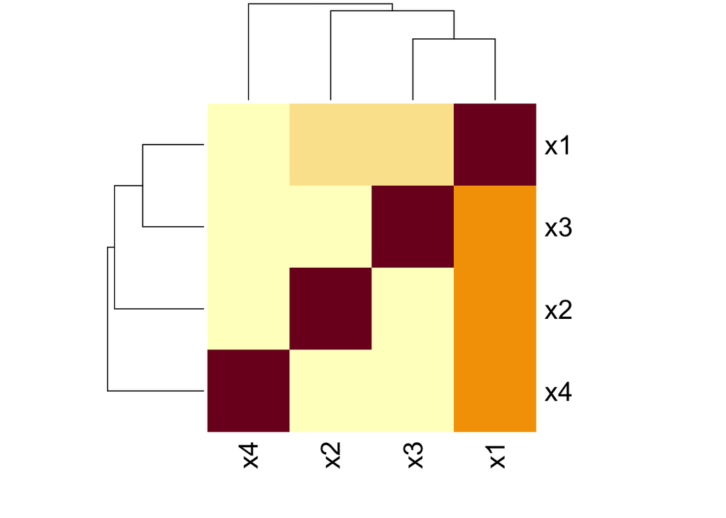

```r
heatmap(cor(gendata))
```

```r
cov(zeta)
```

```
##         [,1]
## [1,] 1.07084
```

```r
cov(epsilon)
```

```
##               [,1]         [,2]          [,3]          [,4]
## [1,]  0.2677099756  0.016246252  0.0137309838 -0.0007682605
## [2,]  0.0162462517  0.147023692 -0.0033355054  0.0037804679
## [3,]  0.0137309838 -0.003335505  0.1076915789 -0.0009544909
## [4,] -0.0007682605  0.003780468 -0.0009544909  0.0942931770
```

Consequently, we observe the model fit to be off - look at the R2 values and negative variance value for x1.

```r
summary(cfa('f1=~x1+x2+x3+x4', data = gendata), rsquare = T)
```

```
## lavaan 0.6-10 ended normally after 46 iterations
##
##   Estimator                                         ML
##   Optimization method                           NLMINB
##   Number of model parameters                         8
##
##   Number of observations                           500
##
## Model Test User Model:
##
##   Test statistic                                 1.089
##   Degrees of freedom                                 2
##   P-value (Chi-square)                           0.580
##
## Parameter Estimates:
##
##   Standard errors                             Standard
##   Information                                 Expected
##   Information saturated (h1) model          Structured
##
## Latent Variables:
##                    Estimate  Std.Err  z-value  P(>|z|)
##   f1 =~
##     x1                1.000
##     x2                0.553    0.011   48.504    0.000
##     x3                0.483    0.010   49.461    0.000
##     x4                0.399    0.009   43.802    0.000
##
## Variances:
##                    Estimate  Std.Err  z-value  P(>|z|)
##    .x1               -0.002    0.013   -0.179    0.858
##    .x2                0.146    0.010   14.558    0.000
##    .x3                0.107    0.007   14.461    0.000
##    .x4                0.094    0.006   14.971    0.000
##     f1                2.407    0.153   15.770    0.000
##
## R-Square:
##                    Estimate
##     x1                   NA
##     x2                0.834
##     x3                0.840
##     x4                0.802
```

```r
summary(miive('f1=~x1+x2+x3+x4', data = gendata, var.cov = T))
```

```
## MIIVsem (0.5.8) results
##
## Number of observations                                                    500
## Number of equations                                                         3
## Estimator                                                           MIIV-2SLS
## Standard Errors                                                      standard
## Missing                                                              listwise
##
##
## Parameter Estimates:
##
##
## STRUCTURAL COEFFICIENTS:
##                    Estimate  Std.Err  z-value  P(>|z|)   Sargan   df   P(Chi)
##   f1 =~
##     x1                1.000
##     x2                0.553    0.012   47.781    0.000    1.072    1    0.300
##     x3                0.482    0.010   48.435    0.000    0.124    1    0.725
##     x4                0.400    0.009   43.239    0.000    0.426    1    0.514
##
## INTERCEPTS:
##                    Estimate  Std.Err  z-value  P(>|z|)
##     x1                0.000
##     x2               -0.022    0.017   -1.293    0.196
##     x3                0.011    0.015    0.756    0.450
##     x4               -0.001    0.014   -0.058    0.954
##
## VARIANCES:
##                    Estimate  Std.Err  z-value  P(>|z|)
##     f1                2.407
##     x1               -0.002
##     x2                0.146
##     x3                0.107
##     x4                0.095
```

I then generated data based directly on the covariance matrix for the observed data.

Here you can see that the covariance matrix of y actually (finally!) follows the true DGM.

```r
loading%*%varcov_latent%*%t(loading) + varcov_epsilon
```

```
##      [,1] [,2]   [,3] [,4]
## [1,] 1.25 0.80 0.7000 0.60
## [2,] 0.80 0.80 0.5600 0.48
## [3,] 0.70 0.56 0.6125 0.42
## [4,] 0.60 0.48 0.4200 0.45
```

```r
#generate data based on the covariance matrix of observed data
y <- mvrnorm(n = N,
             mu = rep(0, 4),
             Sigma = (loading%*%varcov_latent%*%t(loading) + varcov_epsilon))
cov(y)
```

```
##           [,1]      [,2]      [,3]      [,4]
## [1,] 1.3279725 0.8743990 0.7693285 0.6574308
## [2,] 0.8743990 0.8637937 0.6118357 0.5324193
## [3,] 0.7693285 0.6118357 0.6591396 0.4574006
## [4,] 0.6574308 0.5324193 0.4574006 0.4824875
```

```r
colnames(y) <- paste0('x', c(1:4))
summary(cfa('f1=~x1+x2+x3+x4', data = y), rsquare = T)
```

```
## lavaan 0.6-10 ended normally after 27 iterations
##
##   Estimator                                         ML
##   Optimization method                           NLMINB
##   Number of model parameters                         8
##
##   Number of observations                           500
##
## Model Test User Model:
##
##   Test statistic                                 1.544
##   Degrees of freedom                                 2
##   P-value (Chi-square)                           0.462
##
## Parameter Estimates:
##
##   Standard errors                             Standard
##   Information                                 Expected
##   Information saturated (h1) model          Structured
##
## Latent Variables:
##                    Estimate  Std.Err  z-value  P(>|z|)
##   f1 =~
##     x1                1.000
##     x2                0.803    0.025   32.021    0.000
##     x3                0.698    0.022   31.646    0.000
##     x4                0.602    0.019   32.277    0.000
##
## Variances:
##                    Estimate  Std.Err  z-value  P(>|z|)
##    .x1                0.233    0.020   11.494    0.000
##    .x2                0.158    0.013   11.719    0.000
##    .x3                0.126    0.011   11.925    0.000
##    .x4                0.086    0.007   11.569    0.000
##     f1                1.092    0.084   13.053    0.000
##
## R-Square:
##                    Estimate
##     x1                0.824
##     x2                0.816
##     x3                0.809
##     x4                0.822
```

```r
summary(miive('f1=~x1+x2+x3+x4', data = y, var.cov = T))
```

```
## MIIVsem (0.5.8) results
##
## Number of observations                                                    500
## Number of equations                                                         3
## Estimator                                                           MIIV-2SLS
## Standard Errors                                                      standard
## Missing                                                              listwise
##
##
## Parameter Estimates:
##
##
## STRUCTURAL COEFFICIENTS:
##                    Estimate  Std.Err  z-value  P(>|z|)   Sargan   df   P(Chi)
##   f1 =~
##     x1                1.000
##     x2                0.803    0.025   31.789    0.000    0.798    1    0.372
##     x3                0.698    0.022   31.996    0.000    0.087    1    0.768
##     x4                0.601    0.019   32.176    0.000    1.411    1    0.235
##
## INTERCEPTS:
##                    Estimate  Std.Err  z-value  P(>|z|)
##     x1                0.000
##     x2                0.005    0.025    0.207    0.836
##     x3               -0.012    0.022   -0.555    0.579
##     x4               -0.029    0.019   -1.552    0.121
##
## VARIANCES:
##                    Estimate  Std.Err  z-value  P(>|z|)
##     f1                1.093
##     x1                0.233
##     x2                0.158
##     x3                0.126
##     x4                0.086
```

I then tried another random number generating function, ‘rmvnorm’ from the mvtnorm package (looks very likely to the previous ‘mvrnorm’ function).

Again, the covariance matrix of simulated data looks good.

```r
#data generation
set.seed(1234+seed)
zeta <- rnorm(n = N, mean = 0, sd = sqrt(varcov_latent))

set.seed(1234+seed)
epsilon <- mvtnorm::rmvnorm(n = N,
                   mean = rep(0, 4),
                   sigma = varcov_epsilon) #n*p matrix, generate error terms
#compute observed variables
gendata <- t(loading %*% t(zeta)) + epsilon
colnames(gendata) <- paste0('x', c(1:4))
cov(gendata)
```

```
##           x1        x2        x3        x4
## x1 1.4145855 0.9056629 0.7882901 0.6863215
## x2 0.9056629 0.8575134 0.6203565 0.5275810
## x3 0.7882901 0.6203565 0.6581817 0.4714353
## x4 0.6863215 0.5275810 0.4714353 0.4899698
```

And so does the model fits. The R2 values and variances also follow the true DGM.

```r
summary(cfa('f1=~x1+x2+x3+x4', data = gendata), rsquare = T)
```

```
## lavaan 0.6-10 ended normally after 30 iterations
##
##   Estimator                                         ML
##   Optimization method                           NLMINB
##   Number of model parameters                         8
##
##   Number of observations                           500
##
## Model Test User Model:
##
##   Test statistic                                 2.279
##   Degrees of freedom                                 2
##   P-value (Chi-square)                           0.320
##
## Parameter Estimates:
##
##   Standard errors                             Standard
##   Information                                 Expected
##   Information saturated (h1) model          Structured
##
## Latent Variables:
##                    Estimate  Std.Err  z-value  P(>|z|)
##   f1 =~
##     x1                1.000
##     x2                0.778    0.024   31.900    0.000
##     x3                0.686    0.021   32.445    0.000
##     x4                0.590    0.018   32.236    0.000
##
## Variances:
##                    Estimate  Std.Err  z-value  P(>|z|)
##    .x1                0.256    0.022   11.779    0.000
##    .x2                0.156    0.013   11.817    0.000
##    .x3                0.113    0.010   11.492    0.000
##    .x4                0.086    0.007   11.621    0.000
##     f1                1.156    0.089   12.989    0.000
##
## R-Square:
##                    Estimate
##     x1                0.819
##     x2                0.817
##     x3                0.829
##     x4                0.824
```

```r
summary(miive('f1=~x1+x2+x3+x4', data = gendata, var.cov = T))
```

```
## MIIVsem (0.5.8) results
##
## Number of observations                                                    500
## Number of equations                                                         3
## Estimator                                                           MIIV-2SLS
## Standard Errors                                                      standard
## Missing                                                              listwise
##
##
## Parameter Estimates:
##
##
## STRUCTURAL COEFFICIENTS:
##                    Estimate  Std.Err  z-value  P(>|z|)   Sargan   df   P(Chi)
##   f1 =~
##     x1                1.000
##     x2                0.777    0.024   32.156    0.000    1.536    1    0.215
##     x3                0.686    0.021   32.039    0.000    0.020    1    0.888
##     x4                0.590    0.018   32.409    0.000    1.901    1    0.168
##
## INTERCEPTS:
##                    Estimate  Std.Err  z-value  P(>|z|)
##     x1                0.000
##     x2                0.008    0.025    0.324    0.746
##     x3                0.027    0.022    1.206    0.228
##     x4                0.006    0.019    0.345    0.730
##
## VARIANCES:
##                    Estimate  Std.Err  z-value  P(>|z|)
##     f1                1.157
##     x1                0.256
##     x2                0.156
##     x3                0.113
##     x4                0.086
```

## Redo of the previous 2 factor model

Here I redid the previous 2 factor model using the rmvnorm function instead, and we can see that the new simulated data now did follow the true DGM specification, and the R2 values are correct based on our specification.

```r
#####2#####
N <- 500
mean_latent <- c(0,0)
varcov_latent <- matrix(c(1,.5,
                          .5, 1), nrow = 2)
loading <- matrix(c(1,0,
                    .8,0,
                    .7,0,
                    .6,0,
                    0,1,
                    0,.85,
                    0,.75,
                    0,.65), nrow = 8, byrow = T)
varcov_epsilon <- diag(.25, nrow = 8)

set.seed(1234+seed)
zeta <- mvtnorm::rmvnorm(n = N, mean = mean_latent, sigma = varcov_latent)
cov(zeta)
```

```
##           [,1]      [,2]
## [1,] 1.0514869 0.5154812
## [2,] 0.5154812 0.9574653
```

```r
set.seed(1234+seed)
epsilon <- mvtnorm::rmvnorm(n = N,
                            mean = rep(0, 8),
                            sigma = varcov_epsilon) #n*p matrix, generate error terms
cov(epsilon)
```

```
##              [,1]          [,2]         [,3]         [,4]          [,5]         [,6]
## [1,]  0.236855086  0.0012012616 -0.002187133  0.026319320 -0.0261080662  0.007203176
## [2,]  0.001201262  0.2334750078  0.006653166 -0.011111354  0.0003312219 -0.013228513
## [3,] -0.002187133  0.0066531658  0.243138554  0.005322608 -0.0053508743  0.001351945
## [4,]  0.026319320 -0.0111113538  0.005322608  0.235620853 -0.0076808458  0.023818237
## [5,] -0.026108066  0.0003312219 -0.005350874 -0.007680846  0.2793093459  0.001198963
## [6,]  0.007203176 -0.0132285126  0.001351945  0.023818237  0.0011989633  0.236932527
## [7,] -0.012785523  0.0009644562  0.019102870 -0.008602798  0.0174831206  0.012265146
## [8,] -0.006639387 -0.0091816403 -0.018709680  0.003702877  0.0004855675 -0.019110849
##               [,7]          [,8]
## [1,] -0.0127855231 -0.0066393868
## [2,]  0.0009644562 -0.0091816403
## [3,]  0.0191028698 -0.0187096799
## [4,] -0.0086027977  0.0037028772
## [5,]  0.0174831206  0.0004855675
## [6,]  0.0122651464 -0.0191108486
## [7,]  0.2553298071  0.0113159081
## [8,]  0.0113159081  0.2649695085
```

```r
#compute observed variables
gendata <- t(loading %*% t(zeta)) + epsilon

cov(gendata)
```

```
##           [,1]      [,2]      [,3]      [,4]      [,5]      [,6]      [,7]      [,8]
## [1,] 1.3309374 0.8798770 0.7005750 0.6556982 0.5483916 0.4803096 0.3862772 0.3692775
## [2,] 0.8798770 0.9391434 0.5712497 0.4944377 0.4581870 0.3637743 0.3189066 0.2904183
## [3,] 0.7005750 0.5712497 0.6909052 0.4080305 0.3686030 0.3085599 0.2772998 0.2261048
## [4,] 0.6556982 0.4944377 0.4080305 0.5970059 0.3600223 0.3272349 0.2480873 0.2442052
## [5,] 0.5483916 0.4581870 0.3686030 0.3600223 1.2719021 0.8363048 0.7534420 0.6827361
## [6,] 0.4803096 0.3637743 0.3085599 0.3272349 0.8363048 0.9394641 0.6313817 0.5552134
## [7,] 0.3862772 0.3189066 0.2772998 0.2480873 0.7534420 0.6313817 0.8009347 0.5174882
## [8,] 0.3692775 0.2904183 0.2261048 0.2442052 0.6827361 0.5552134 0.5174882 0.7325248
```

```r
loading%*%varcov_latent%*%t(loading) + varcov_epsilon
```

```
##       [,1] [,2]   [,3]  [,4] [,5]   [,6]   [,7]   [,8]
## [1,] 1.250 0.80 0.7000 0.600 0.50 0.4250 0.3750 0.3250
## [2,] 0.800 0.89 0.5600 0.480 0.40 0.3400 0.3000 0.2600
## [3,] 0.700 0.56 0.7400 0.420 0.35 0.2975 0.2625 0.2275
## [4,] 0.600 0.48 0.4200 0.610 0.30 0.2550 0.2250 0.1950
## [5,] 0.500 0.40 0.3500 0.300 1.25 0.8500 0.7500 0.6500
## [6,] 0.425 0.34 0.2975 0.255 0.85 0.9725 0.6375 0.5525
## [7,] 0.375 0.30 0.2625 0.225 0.75 0.6375 0.8125 0.4875
## [8,] 0.325 0.26 0.2275 0.195 0.65 0.5525 0.4875 0.6725
```

```r
colnames(gendata) <- paste0('x', c(1:8))

summary(miive(model = 'f1=~x1+x2+x3+x4
            f2=~x5+x6+x7+x8',
              data = gendata,
              var.cov = T))
```

```
## MIIVsem (0.5.8) results
##
## Number of observations                                                    500
## Number of equations                                                         6
## Estimator                                                           MIIV-2SLS
## Standard Errors                                                      standard
## Missing                                                              listwise
##
##
## Parameter Estimates:
##
##
## STRUCTURAL COEFFICIENTS:
##                    Estimate  Std.Err  z-value  P(>|z|)   Sargan   df   P(Chi)
##   f1 =~
##     x1                1.000
##     x2                0.784    0.029   26.824    0.000    9.048    5    0.107
##     x3                0.638    0.027   23.770    0.000    6.685    5    0.245
##     x4                0.578    0.025   23.243    0.000    7.756    5    0.170
##   f2 =~
##     x5                1.000
##     x6                0.829    0.032   25.780    0.000    7.469    5    0.188
##     x7                0.753    0.030   24.890    0.000    3.162    5    0.675
##     x8                0.672    0.030   22.255    0.000    3.971    5    0.554
##
## INTERCEPTS:
##                    Estimate  Std.Err  z-value  P(>|z|)
##     x1                0.000
##     x2                0.015    0.028    0.558    0.577
##     x3                0.031    0.026    1.173    0.241
##     x4                0.034    0.024    1.406    0.160
##     x5                0.000
##     x6               -0.012    0.029   -0.417    0.677
##     x7                0.001    0.028    0.031    0.975
##     x8                0.003    0.028    0.097    0.923
##
## VARIANCES:
##                    Estimate  Std.Err  z-value  P(>|z|)
##     f1                1.115
##     f2                1.006
##     x1                0.217
##     x2                0.247
##     x3                0.240
##     x4                0.221
##     x5                0.264
##     x6                0.245
##     x7                0.231
##     x8                0.274
##
## COVARIANCES:
##                    Estimate  Std.Err  z-value  P(>|z|)
##   f1 ~~
##     f2                0.566
```

```r
summary(cfa(model = 'f1=~x1+x2+x3+x4
            f2=~x5+x6+x7+x8',
            data = gendata), rsquare = T)
```

```
## lavaan 0.6-10 ended normally after 30 iterations
##
##   Estimator                                         ML
##   Optimization method                           NLMINB
##   Number of model parameters                        17
##
##   Number of observations                           500
##
## Model Test User Model:
##
##   Test statistic                                26.128
##   Degrees of freedom                                19
##   P-value (Chi-square)                           0.127
##
## Parameter Estimates:
##
##   Standard errors                             Standard
##   Information                                 Expected
##   Information saturated (h1) model          Structured
##
## Latent Variables:
##                    Estimate  Std.Err  z-value  P(>|z|)
##   f1 =~
##     x1                1.000
##     x2                0.789    0.029   26.913    0.000
##     x3                0.636    0.027   23.993    0.000
##     x4                0.582    0.025   23.260    0.000
##   f2 =~
##     x5                1.000
##     x6                0.830    0.032   25.778    0.000
##     x7                0.751    0.030   24.906    0.000
##     x8                0.674    0.030   22.302    0.000
##
## Covariances:
##                    Estimate  Std.Err  z-value  P(>|z|)
##   f1 ~~
##     f2                0.565    0.059    9.531    0.000
##
## Variances:
##                    Estimate  Std.Err  z-value  P(>|z|)
##    .x1                0.218    0.025    8.614    0.000
##    .x2                0.247    0.021   11.724    0.000
##    .x3                0.240    0.018   13.164    0.000
##    .x4                0.220    0.016   13.417    0.000
##    .x5                0.264    0.026   10.106    0.000
##    .x6                0.245    0.021   11.559    0.000
##    .x7                0.232    0.019   12.150    0.000
##    .x8                0.274    0.020   13.357    0.000
##     f1                1.110    0.086   12.979    0.000
##     f2                1.005    0.081   12.405    0.000
##
## R-Square:
##                    Estimate
##     x1                0.836
##     x2                0.737
##     x3                0.652
##     x4                0.630
##     x5                0.792
##     x6                0.739
##     x7                0.710
##     x8                0.626
```

## Summary

The problem seems to be with the MASS package’s mvrnorm function. However, I was not able to pinpoint where/how exactly it’s causing the issue. Because the the covariance matrices for latent factor and error terms generated DIRECTLY using the function DID follow the specification, it was only when I used these two data matrices (zeta and epsilon) to compute the observed variables that the issue occurred. Similarly, when I simulated the observed variables directly using the mvrnorm function, it also followed the specified structure. The problem was not with the equation used to compute observed variables because 1, it is the correct theoretical equation, and 2, when I switched to rmvnorm from the mvtnorm package for computation, the observed variables still followed the true DGM structure.